# Phylogenetics

Valeria

2024-10-21

## 1 task. Construct an evolutionary tree based on human mtDNA data.

Using given data I made alignments using MAFT and made a tree using IQTREE. To calculate the age of mt Eve I used two samples that are far away from each other (KX440262.1 - sample from Tunis and FJ713601.1 from Central Africa).

[figure not shown]

I tried to reconstruct this tree using one sample of Denisova and one of Neanderthalensis as an outgroup, but got a very strange result with one sample of homo sapience together with Neanderthals. (Added also names of haplogroups)

```r
knitr::include_graphics("D:/itmo/Phylogenetics/images/Tree_with_N_and_D.svg")
```

[figure not shown]

It didn’t happed when I used all samples to bild phylogenetic tree which will be shown in the 3rd task.

## 2 task. Estimate the age of the mitochondrial Eve and most recent ancestor of all non-Africans.

## Mitochondrial Eve

To estimate the age of the mitochondrial Eve we need to know value of substitutions per site (can be calculated using two taxas and the difference between them) and mutation rate (value that is known from the literature). $Age = \dfrac{\text{substitutions per site}}{\text{mutation rate}}$ To calculate substitutions per site I used MEGA and Pairwise distance estimation.

Title: Phylogenetic Analysis

Description

Analysis ====================

Analysis = ====================

Scope = Pairs of taxa

Estimate Variance = ====================

Variance Estimation Method = None

Substitution Model = ====================

Substitutions Type = Nucleotide

Model/Method = Maximum Composite Likelihood

Substitutions to Include = d: Transitions + Transversions

Rates and Patterns = ====================

Rates among Sites = Uniform Rates

Pattern among Lineages = Same (Homogeneous)

Data Subset to Use = ====================

Gaps/Missing Data Treatment = Pairwise deletion

Select Codon Positions = 1st,2nd,3rd,Non-Coding

[1] #KX440262.1_Homo_sapiens_isolate_JT76_haplogroup_J2a2d1_mitochondrion_complete_genome

[2] #FJ713601.1_Homo_sapiens_haplogroup_L1c1d_mitochondrion_complete_genome

[ 1 2 ]

[1]

[2] **0.00577**

Table. Estimates of Evolutionary Divergence between Sequences

In the literature as the observed evolutionary rates range μ is estimated from 4.33 × 10–8 (95% CI 3.90–4.82 × 10–8) mutations per site per year (msy) for the most recent period to 1.91 × 10–8 (95% CI 1.72–2.10 × 10–8) msy for the oldest period (40,160 ± 4658 ya). https://www.nature.com/articles/s41598-021-84583-1

As we need to calculate the age of Eve and the dna was mutating with the increasing speed I would take the average.

$$Age = 0.00577/(3.12*10^{-8}) = \textbf{184935.9 years}$$

## Most recent ancestor of all non-Africans

The same steps can be done to estimate the age of most recent ancestor of all non-Africans. Based on phylogeny tree topology I chose Homo_sapiens_isolate_Y453_haplogroup_L4b2a1 from Yemeni and KT698006.1_Homo_sapiens_isolate_52_Sb_haplogroup_U2e2a4 from Serbia.

Title:

Description

Analysis ====================

Analysis = ====================

Scope = Pairs of taxa

Estimate Variance = ====================

Variance Estimation Method = None

Substitution Model = ====================

Substitutions Type = Nucleotide

Model/Method = p-distance

Substitutions to Include = d: Transitions + Transversions

Rates and Patterns = ====================

Rates among Sites = Uniform Rates

Pattern among Lineages = Same (Homogeneous)

Data Subset to Use = ====================

Gaps/Missing Data Treatment = Pairwise deletion

Select Codon Positions = 1st,2nd,3rd,Non-Coding

[1] #KM986608.1_Homo_sapiens_isolate_Y453_haplogroup_L4b2a1_mitochondrion_complete_genome

[2] #KT698006.1_Homo_sapiens_isolate_52_Sb_haplogroup_U2e2a4_mitochondrion_complete_genome

[ 1 2 ]

[1]

[2] **0.00326**

104487 years is the age of the most recent ancestor of all non-Africans based on the tree topology and our data.

## 3 task. Estimate the separation time and branching order of the Neanderthal and Denisovan population.

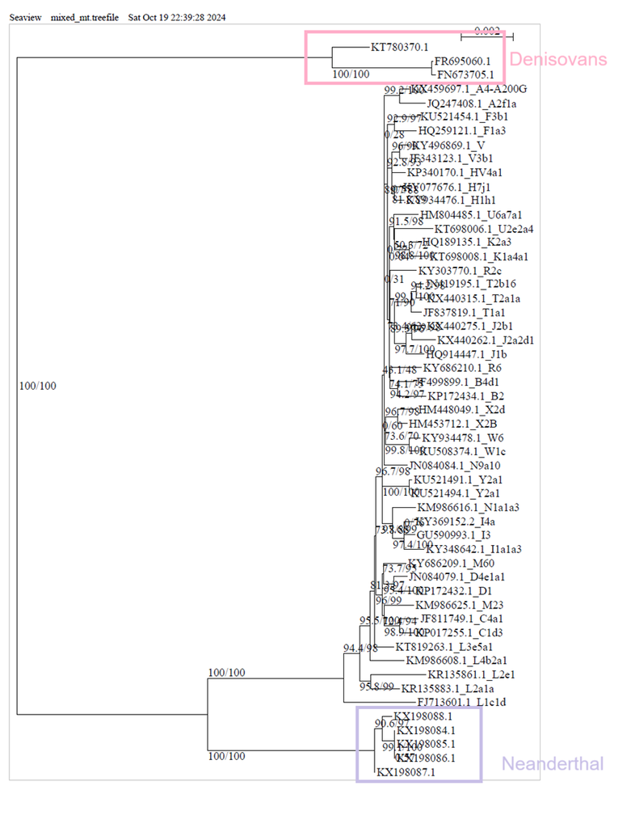

```r
knitr::include_graphics("D:/itmo/Phylogenetics/images/Рисунок2.png")
```

According to the tree humans and neanderthals have more resent ancestor then humans and denisovans so the last one separated earlier than neanderthals.

I calculated pairwise matrix in MEGA with all samples using MAFT alignments and calculated average score:

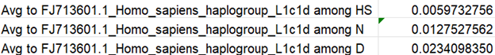

```r
knitr::include_graphics("D:/itmo/Phylogenetics/images/avg.png")
```

Time when Neanderthalensis separated is $0.013/(3.12 × 10^8 )$= 416667 years ago and for Denisovans is 750315.2254